# MidtermProject

Author

Kessie SHEN

Central Line-Associated Bloodstream infections (CLABSI) in California Hospitals

## Introduction

The NHSN defines CLABSI as a laboratory-confirmed bloodstream infection that occurs in a patient who had a central venous catheter placed within 48 hours prior to the date of blood culture collection, with no other source of bacteremia or fungemia identified. This definition is based on monitoring rather than clinical presentation and does not stipulate any requirements regarding symptoms or signs of infection. Since it is often difficult to determine whether a bloodstream infection is related to the central venous catheter itself or to a secondary source of infection (such as an abdominal abscess or pneumonia), the NHSN’s definition of CLABSI may overestimate the true incidence of catheter-related infections. As a result, data interpretation can be more complex.

## Question:How do CLABSI rates differ by type of hospital and by region in California?

## Data Wrangling

```r
library(data.table)
library(dplyr)
folder_path <- "/Users/ckkkkkkkj/Desktop/566Midproj"
file_paths <- list.files(folder_path, pattern = "*.csv", full.names = TRUE)

#Rename Infections_Reported and Observed_infections to InfectNumber.
#Rename Pre_Infect.
read_and_rename <- function(file_path) {
  data <- fread(file_path)

 col_rename <- list(
    "Infections_Reported" = "InfectNumber",
    "Observed_infections" = "InfectNumber",
    "Observed_Infections" = "InfectNumber",
    "Infections_Predicted" = "Pred_Infect",
    "Predicted_infections" = "Pred_Infect",
    "Predicted_Infections" = "Pred_Infect",
    "Central_line_days" = "CentralLINE_Days",
    "Central_Line_Days" = "CentralLINE_Days",
    "Central_line_Days" = "CentralLINE_Days",
    "95%Confidence_Interval_Low_Limit" = "SIR_CI_95_Lower_Limit",
    "95%Confidence_Interval_Upper_Limit" = "SIR_CI_95_Upper_Limit",
    "Statistical_Interpretation" = "Comparison",
    "Hospital_Type" = "Facility_Type",
    "Hospital_Category_RiskAdjustment" = "Facility_Category"
  )
 for (col in names(data)) {
    if (col %in% names(col_rename)) {
      setnames(data, old = col, new = col_rename[[col]])
    }
  }

  return(data)
}
combined_data <- rbindlist(lapply(file_paths, read_and_rename), use.names = TRUE, fill = TRUE)
print(combined_data)
```

```
        Year      State                                                    HAI
      <char>     <char>                                                 <char>
   1:   2013 California                                                 CLABSI
   2:   2013 California                                                 CLABSI
   3:   2013 California                                                 CLABSI
   4:   2013 California                                                 CLABSI
   5:   2013 California                                                 CLABSI
  ---
5215:   2023 California Central Line-Associated Bloodstream Infection (CLABSI)
5216:   2023 California Central Line-Associated Bloodstream Infection (CLABSI)
5217:   2023 California Central Line-Associated Bloodstream Infection (CLABSI)
5218:   2023 California Central Line-Associated Bloodstream Infection (CLABSI)
5219:   2023 California Central Line-Associated Bloodstream Infection (CLABSI)
                                     Facility_Name1
                                             <char>
```

[output cut: 115 more lines]

# Data Dictionary.after reading the Description Data Dictionary，I believe that “Facility ID” is primarily a unique identifier used to track information about hospitals or healthcare facilities in the California Department of Public Health (CDPH) Electronic Licensing Management System (ELMS). It is important for data management and record keeping, but it has little impact on the analysis of central line-associated bloodstream infection (CLABSI) data itself and does not directly affect the analysis of infection rates or hospital performance. Therefore, I deleted it during the merging process. Clip_Adherence_Percent was reported in only four years, and On_Track_Toward_2020_Goal appeared only in 2017 and 2018, resulting in insufficient data. For this analysis, I have temporarily removed them.

```r
cleaned_data <- combined_data %>%
  select(-Clip_Adherence_Percent, -FACID1, -FACID2, -FACID3, -Facility_ID1, -HAI,-Facility_ID,-Facility_Name1,-Facility_Name2,-Facility_Name3,-Facility_Name,-`On_Track_Toward_2020_Goal (0.80, 2017)`,-`On_Track_Toward_2020_Goal (0.7, 2018)`,-On_Track)
print(cleaned_data)
```

```
        Year      State       County InfectNumber Pred_Infect CentralLINE_Days
      <char>     <char>       <char>        <int>       <num>            <int>
   1:   2013 California   Santa Cruz            4       10.35             7353
   2:   2013 California Kings-Fresno            4        7.48             5791
   3:   2013 California       Fresno            0        0.00                4
   4:   2013 California       Orange           13       14.39             8191
   5:   2013 California      Alameda            6       20.33            11238
  ---
5215:   2023 California      Ventura            6        3.79             3638
5216:   2023 California      Ventura            0        0.26              322
5217:   2023 California         Yolo            0        0.53              878
5218:   2023 California         Yolo            0        1.53             2219
5219:   2023 California         Yuba            2        4.65             6763
        SIR SIR_CI_95_Lower_Limit SIR_CI_95_Upper_Limit           Comparison
      <num>                 <num>                 <num>               <char>
```

[output cut: 37 more lines]

# NA

```r
cleaned_data1 <- cleaned_data %>%
  mutate(across(where(is.numeric), ~ ifelse(is.na(.), mean(., na.rm = TRUE), .)))
print(cleaned_data1)
```

```
        Year      State       County InfectNumber Pred_Infect CentralLINE_Days
      <char>     <char>       <char>        <num>       <num>            <num>
   1:   2013 California   Santa Cruz            4       10.35             7353
   2:   2013 California Kings-Fresno            4        7.48             5791
   3:   2013 California       Fresno            0        0.00                4
   4:   2013 California       Orange           13       14.39             8191
   5:   2013 California      Alameda            6       20.33            11238
  ---
5215:   2023 California      Ventura            6        3.79             3638
5216:   2023 California      Ventura            0        0.26              322
5217:   2023 California         Yolo            0        0.53              878
5218:   2023 California         Yolo            0        1.53             2219
5219:   2023 California         Yuba            2        4.65             6763
            SIR SIR_CI_95_Lower_Limit SIR_CI_95_Upper_Limit
          <num>                 <num>                 <num>
```

[output cut: 37 more lines]

## CLABSI infection rates between different regions in California.

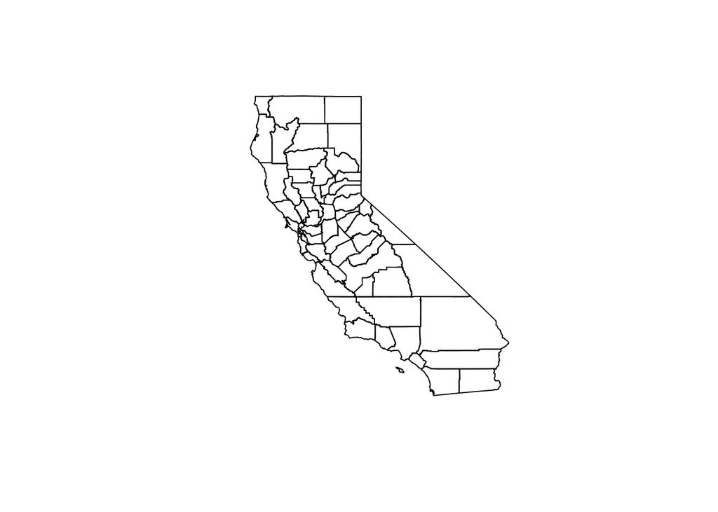

```r
library(sf)
library(tmap)
clabsi_by_County <- cleaned_data1 %>%
  group_by(County) %>%
  summarize(
    Total_Infections = sum(InfectNumber, na.rm = TRUE),
    Total_Central_Line_Days = sum(CentralLINE_Days, na.rm = TRUE)
  ) %>%
  mutate(CLABSI_Rate = (Total_Infections / Total_Central_Line_Days) * 1000)
#Go to the California State Geoportal,download a shapefile for California counties.
california_map <- st_read("/Users/ckkkkkkkj/Desktop/California_Counties_/Counties.shp")
plot(st_geometry(california_map))
```

```r
print(clabsi_by_County)
```

```
# A tibble: 61 × 4
   County                 Total_Infections Total_Central_Line_Days CLABSI_Rate
   <chr>                             <dbl>                   <dbl>       <dbl>
 1 ""                             20399                  23689271        0.861
 2 "Alameda"                       1070.                  1232060.       0.868
 3 "Alameda-Contra Costa"            11                     11239        0.979
 4 "Amador"                          10                     19097        0.524
 5 "Butte"                           42                    181631        0.231
 6 "Calaveras"                        1                      5785        0.173
 7 "Colusa"                           9.42                  12715.       0.741
 8 "Contra Costa"                   473                    536568        0.882
 9 "Del Norte"                        1                      7799        0.128
10 "El Dorado"                        8                     46191        0.173
# ℹ 51 more rows
```

```r
california_map <- california_map %>%
  left_join(clabsi_by_County, by = c("CountyName" = "County"))
tmap_mode("plot")  # Set to plot mode (use "view" for interactive)
```

```
tmap mode set to plotting
```

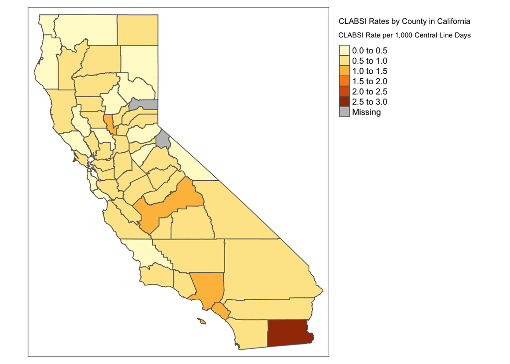

```r
# Create the map
tm_shape(california_map) +
  tm_fill("CLABSI_Rate", title = "CLABSI Rate per 1,000 Central Line Days") +
  tm_borders() +
  tm_layout(title = "CLABSI Rates by County in California",
            legend.outside = TRUE)
```

[figure not shown]

```r
#The map may reveal geographic trends, such as urban versus rural differences in CLABSI rates

# Visual
library(ggplot2)
ggplot(clabsi_by_County, aes(x = County, y = CLABSI_Rate, fill = County)) +
  geom_boxplot() +
  labs(title = "CLABSI Rates by County in California",
       x = "County",
       y = "CLABSI Rate per 1000 Central Line Days") +
  theme(axis.text.x = element_text(angle = 45, hjust = 1))
```

```r
#Factors such as healthcare quality, hospital practices, and patient populations may contribute to these variations
```

#Data Exploration

```r
summary(cleaned_data1)
```

```
     Year              State              County           InfectNumber
 Length:5219        Length:5219        Length:5219        Min.   :   0.000
 Class :character   Class :character   Class :character   1st Qu.:   0.000
 Mode  :character   Mode  :character   Mode  :character   Median :   2.000
                                                          Mean   :   9.423
                                                          3rd Qu.:   6.000
                                                          Max.   :2594.000
  Pred_Infect       CentralLINE_Days         SIR          SIR_CI_95_Lower_Limit
 Min.   :   0.000   Min.   :      0.0   Min.   : 0.0000   Min.   :0.0000
 1st Qu.:   0.385   1st Qu.:    654.5   1st Qu.: 0.3800   1st Qu.:0.0500
 Median :   2.627   Median :   3087.0   Median : 0.8469   Median :0.3175
 Mean   :  12.074   Mean   :  10716.9   Mean   : 0.8469   Mean   :0.3175
 3rd Qu.:   9.365   3rd Qu.:   8347.0   3rd Qu.: 0.8900   3rd Qu.:0.3300
 Max.   :2869.070   Max.   :2879638.0   Max.   :11.1900   Max.   :7.6700
 SIR_CI_95_Upper_Limit  Comparison           Notes           Facility_Category
 Min.   : 0.070        Length:5219        Length:5219        Length:5219
 1st Qu.: 1.400        Class :character   Class :character   Class :character
 Median : 3.120        Mode  :character   Mode  :character   Mode  :character
 Mean   : 3.329
 3rd Qu.: 3.329
 Max.   :32.710
 Facility_Type         SIR_2015         Months      Met_2020_Goal
 Length:5219        Min.   :0.000   Min.   : 0.00   Length:5219
 Class :character   1st Qu.:1.070   1st Qu.:10.93   Class :character
 Mode  :character   Median :1.093   Median :12.00   Mode  :character
                    Mean   :1.093   Mean   :10.93
                    3rd Qu.:1.093   3rd Qu.:12.00
                    Max.   :7.530   Max.   :12.00
```

```r
str(cleaned_data1)
```

```
Classes 'data.table' and 'data.frame':  5219 obs. of  16 variables:
 $ Year                 : chr  "2013" "2013" "2013" "2013" ...
 $ State                : chr  "California" "California" "California" "California" ...
 $ County               : chr  "Santa Cruz" "Kings-Fresno" "Fresno" "Orange" ...
 $ InfectNumber         : num  4 4 0 13 6 0 0 4 6 3 ...
 $ Pred_Infect          : num  10.35 7.48 0 14.39 20.33 ...
 $ CentralLINE_Days     : num  7353 5791 4 8191 11238 ...
 $ SIR                  : num  0.39 0.54 0.847 0.9 0.3 ...
 $ SIR_CI_95_Lower_Limit: num  0.12 0.17 0.317 0.5 0.12 ...
 $ SIR_CI_95_Upper_Limit: num  0.93 1.29 3.33 1.51 0.61 ...
 $ Comparison           : chr  "Low" "No difference" "Too few to calculate" "No difference" ...
 $ Notes                : chr  "" "† See data dictionary" "" "" ...
 $ Facility_Category    : chr  NA NA NA NA ...
 $ Facility_Type        : chr  NA NA NA NA ...
 $ SIR_2015             : num  1.09 1.09 1.09 1.09 1.09 ...
 $ Months               : num  10.9 10.9 10.9 10.9 10.9 ...
 $ Met_2020_Goal        : chr  NA NA NA NA ...
 - attr(*, ".internal.selfref")=<externalptr>
```

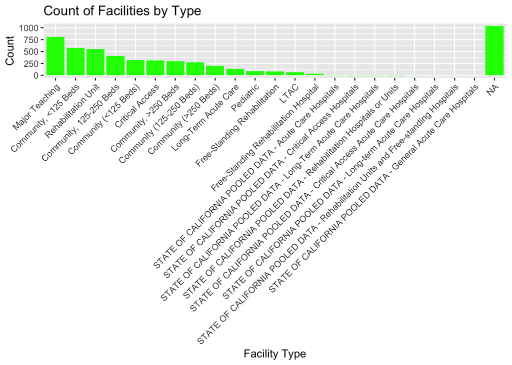

```r
category_summary <- cleaned_data1 %>%
  group_by(Facility_Type) %>%
  summarize(Count = n())
ggplot(category_summary, aes(x = reorder(Facility_Type, -Count), y = Count)) +
  geom_bar(stat = "identity", fill = "green") +
  labs(title = "Count of Facilities by Type", x = "Facility Type", y = "Count") +
  theme(axis.text.x = element_text(angle = 45, hjust = 1))
```

```r
#Because the data for the years 2013, 2014, and 2015 did not include hospital types, the NA portions are also difficult to handle.
```

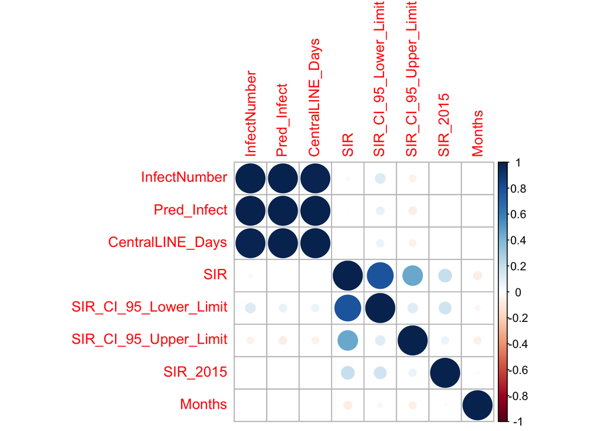

```r
correlation_matrix <- cor(cleaned_data1 %>% select(where(is.numeric)), use = "complete.obs")
library(corrplot)
corrplot(correlation_matrix, method = "circle")
```

```r
summary_by_type <- cleaned_data1 %>%
  group_by(Facility_Type) %>%
  summarize(Mean_InfectRate = mean(InfectNumber, na.rm = TRUE),
            SD_InfectRate = sd(InfectNumber, na.rm = TRUE))

print(summary_by_type)
```

```
# A tibble: 23 × 3
   Facility_Type                         Mean_InfectRate SD_InfectRate
   <chr>                                           <dbl>         <dbl>
 1 Community (125-250 Beds)                        4.61          9.66
 2 Community (<125 Beds)                           0.986         1.68
 3 Community (>250 Beds)                           9.25          6.98
 4 Community, 125-250 Beds                         3.60          7.53
 5 Community, <125 Beds                            1.28          2.37
 6 Community, >250 Beds                            6.58          6.39
 7 Critical Access                                 0.621         2.20
 8 Free-Standing Rehabilitation                    0.636         2.27
 9 Free-Standing Rehabilitation Hospital           0.176         0.387
10 LTAC                                           15.4          13.5
# ℹ 13 more rows
```

#The relationship between the incidence of CLABSI and the size of the hospital

```r
cleaned_data1 <- cleaned_data1 %>%
  mutate(CLABSI_Rate = (InfectNumber / CentralLINE_Days) * 1000)
avg_infect_rate_by_type <- cleaned_data1 %>%
  group_by(Facility_Type) %>%
  summarize(Mean_CLABSI_Rate = mean(CLABSI_Rate, na.rm = TRUE),
            Median_CLABSI_Rate = median(CLABSI_Rate, na.rm = TRUE))

print(avg_infect_rate_by_type)
```

```
# A tibble: 23 × 3
   Facility_Type                         Mean_CLABSI_Rate Median_CLABSI_Rate
   <chr>                                            <dbl>              <dbl>
 1 Community (125-250 Beds)                         0.770              0.633
 2 Community (<125 Beds)                            0.524              0
 3 Community (>250 Beds)                            0.763              0.717
 4 Community, 125-250 Beds                          0.770              0.533
 5 Community, <125 Beds                             0.887              0
 6 Community, >250 Beds                             0.730              0.635
 7 Critical Access                                  0.266              0
 8 Free-Standing Rehabilitation                     0.113              0
 9 Free-Standing Rehabilitation Hospital            0.353              0
10 LTAC                                             1.64               1.44
# ℹ 13 more rows
```

```r
anova_result <- aov(CLABSI_Rate ~ Facility_Type, data = cleaned_data1)
summary(anova_result)
```

```
                Df Sum Sq Mean Sq F value   Pr(>F)
Facility_Type   21    440  20.932   5.713 1.34e-15 ***
Residuals     4064  14891   3.664
---
Signif. codes:  0 '***' 0.001 '**' 0.01 '*' 0.05 '.' 0.1 ' ' 1
1133 observations deleted due to missingness
```

[figure not shown]

```r
#This ANOVA analysis output shows that the different hospital types (Facility_Type) have a statistically significant effect on the CLABSI infection rate.The low p-value and high F-statistic support the conclusion that the differences observed between hospital types are not due to random chance, indicating a substantial variation in CLABSI rates across different hospital types. This finding can inform further analysis to understand why specific hospital types may have higher or lower rates and could guide targeted strategies for reducing CLABSI infections across hospital settings

#The original data direction shows:Specific types of California hospitals are Major Teaching, Pediatric, Community (>250 Beds), Community (125-250 Beds), Community (<125 Beds), Long-term Acute Care (LTAC), Critical Access, Free-Standing Rehabilitation Hospital, and Rehabilitation Unit.
#Define Average Bed Counts by Facility Type,
bed_count_mapping <- c(
  "Pediatric/Teaching Hospital" = 500,
  "Community Hospital" = 200,
  "Critical Access Hospital" = 25,
  "Long-term Acute Care Hospital" = 100,
  "Rehabilitation Unit" = 75
)
# Add a Bed_Count column based on Facility_Type
cleaned_data1 <- cleaned_data1 %>%
  mutate(Bed_Count = bed_count_mapping[Facility_Type])
ggplot(cleaned_data1, aes(x = Bed_Count, y = CLABSI_Rate)) +
  geom_point(alpha = 0.6, color = "darkblue") +
  labs(title = "CLABSI Rate vs. Estimated Bed Count", x = "Estimated Bed Count", y = "CLABSI Rate per 1000 Central Line Days") +
  geom_smooth(method = "lm", color = "red", se = FALSE)
```

```r
#This approximation is only an estimate, but it can be useful for initial exploratory analysis, especially if actual bed count data is unavailable.
```